# Statistical Analysis - Forecasting - Question 2

11/11/2021

# **Entering Dataset**

For this analysis, the dataset “DataLiquor.csv” was used to perform forecasting of liquor selling over the period of 1987 - 2014. This dataset has 336 observations distributed over 4 variables (Time, Year, Month, and Liquor Sales). Below can be found the chunk of code used to retrieve the data and attach it to the workplace in R:

```r
library(readr)
DataLiquor <- read_delim("C:/Users/profz/Desktop/DataLiquor.csv", ";", escape_double = FALSE, trim_ws = TRUE)
head(DataLiquor)
```

```
## # A tibble: 6 x 4
##    Time  Year     M Liquor
##   <dbl> <dbl> <dbl>  <dbl>
## 1     1  1987     1    480
## 2     2  1987     2    467
## 3     3  1987     3    514
## 4     4  1987     4    505
## 5     5  1987     5    534
## 6     6  1987     6    546
```

```r
save(DataLiquor, file = "DataLiquor.RData")
```

# **Loading Packages**

```r
library(openintro)
library(dplyr)
library(ggplot2)
library(e1071)
library(jtools)
library(car)
library(lme4)
library(tidyverse)
library(caret)
library(ggplot2)
```

# **Plotting**

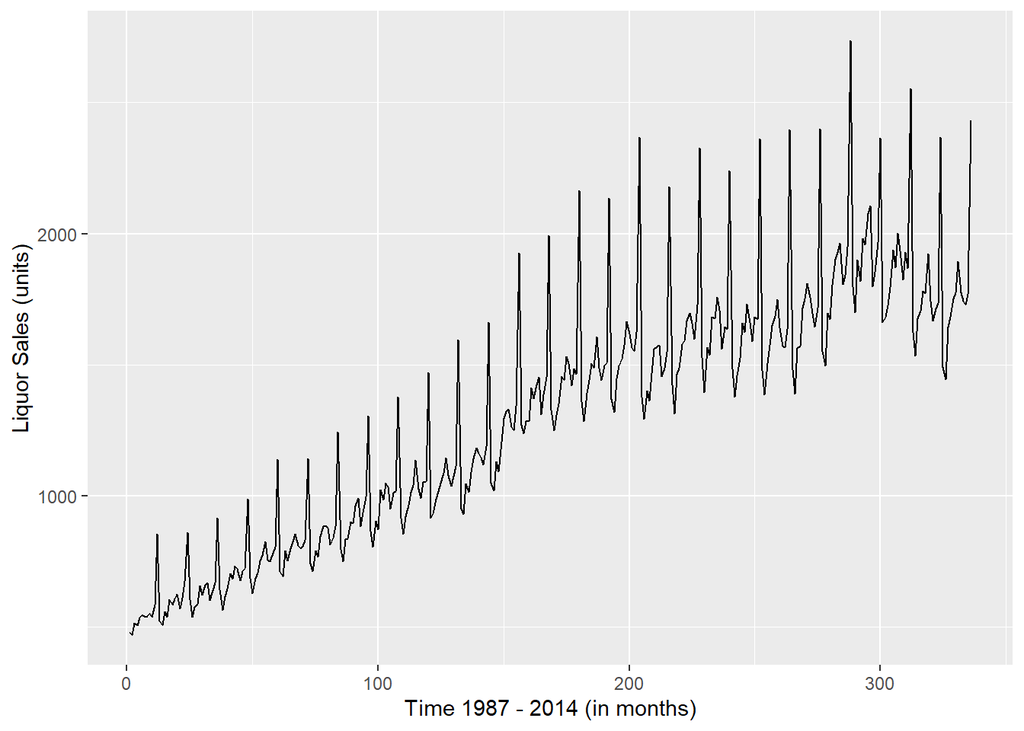

```r
ggplot(DataLiquor, aes(x = Time, y = Liquor)) +
  geom_line() + labs(y="Liquor Sales (units)", x = "Time 1987 - 2014 (in months)")
```

# **Conducting the Regressions**

## **Model 1 - Pure Log Linear**

```r
model_1 <- lm(log1p(DataLiquor$Liquor)~Time, data=DataLiquor)
summary(model_1)
```

```
##
## Call:
## lm(formula = log1p(DataLiquor$Liquor) ~ Time, data = DataLiquor)
##
## Residuals:
##     Min      1Q  Median      3Q     Max
## -0.4200 -0.1013 -0.0078  0.0873  0.5389
##
## Coefficients:
##              Estimate Std. Error t value Pr(>|t|)
## (Intercept) 6.456e+00  1.745e-02   370.0   <2e-16 ***
## Time        3.806e-03  8.975e-05    42.4   <2e-16 ***
## ---
## Signif. codes:  0 '***' 0.001 '**' 0.01 '*' 0.05 '.' 0.1 ' ' 1
##
## Residual standard error: 0.1596 on 334 degrees of freedom
## Multiple R-squared:  0.8433, Adjusted R-squared:  0.8429
## F-statistic:  1798 on 1 and 334 DF,  p-value: < 2.2e-16
```

## **Model 2 - Pure Seasonal Model**

```r
m_1 <- ifelse(DataLiquor$M == 1, 1, 0)
m_2 <- ifelse(DataLiquor$M == 2, 1, 0)
m_3 <- ifelse(DataLiquor$M == 3, 1, 0)
m_4 <- ifelse(DataLiquor$M == 4, 1, 0)
m_5 <- ifelse(DataLiquor$M == 5, 1, 0)
m_6 <- ifelse(DataLiquor$M == 6, 1, 0)
m_7 <- ifelse(DataLiquor$M == 7, 1, 0)
m_8 <- ifelse(DataLiquor$M == 8, 1, 0)
m_9 <- ifelse(DataLiquor$M == 9, 1, 0)
m_10 <- ifelse(DataLiquor$M == 10, 1, 0)
m_11 <- ifelse(DataLiquor$M == 11, 1, 0)
m_12 <- ifelse(DataLiquor$M == 12, 1, 0)
dummies_12 <- data.frame(m_1,m_2,m_3,m_4,m_5,m_6,m_7,m_8,m_9,m_10,m_11,m_12)
DataLiquor$dummies_12 <- dummies_12

model_2 <- lm(log1p(DataLiquor$Liquor)~m_1+m_2+m_3+m_4+m_5+m_6+m_7+m_8+m_9+m_10+m_11+m_12, data=DataLiquor)
summary(model_2)
```

```
##
## Call:
## lm(formula = log1p(DataLiquor$Liquor) ~ m_1 + m_2 + m_3 + m_4 +
##     m_5 + m_6 + m_7 + m_8 + m_9 + m_10 + m_11 + m_12, data = DataLiquor)
##
## Residuals:
##     Min      1Q  Median      3Q     Max
## -0.8587 -0.3077  0.1656  0.3166  0.5346
##
## Coefficients: (1 not defined because of singularities)
##             Estimate Std. Error t value Pr(>|t|)
## (Intercept)  7.45661    0.07345 101.515  < 2e-16 ***
## m_1         -0.47846    0.10388  -4.606 5.91e-06 ***
## m_2         -0.53145    0.10388  -5.116 5.35e-07 ***
## m_3         -0.44052    0.10388  -4.241 2.91e-05 ***
## m_4         -0.43566    0.10388  -4.194 3.54e-05 ***
## m_5         -0.36292    0.10388  -3.494 0.000543 ***
## m_6         -0.35410    0.10388  -3.409 0.000735 ***
## m_7         -0.30639    0.10388  -2.950 0.003414 **
## m_8         -0.33093    0.10388  -3.186 0.001584 **
## m_9         -0.38700    0.10388  -3.726 0.000230 ***
## m_10        -0.36121    0.10388  -3.477 0.000576 ***
## m_11        -0.32556    0.10388  -3.134 0.001882 **
## m_12              NA         NA      NA       NA
## ---
## Signif. codes:  0 '***' 0.001 '**' 0.01 '*' 0.05 '.' 0.1 ' ' 1
##
## Residual standard error: 0.3887 on 324 degrees of freedom
## Multiple R-squared:  0.09846,    Adjusted R-squared:  0.06785
## F-statistic: 3.217 on 11 and 324 DF,  p-value: 0.0003558
```

## **Model 3 - Log Linear + Seasonal**

```r
model_3 <- lm(log1p(DataLiquor$Liquor)~Time+m_1+m_2+m_3+m_4+m_5+m_6+m_7+m_8+m_9+m_10+m_11+m_12, data=DataLiquor)
summary(model_3)
```

```
##
## Call:
## lm(formula = log1p(DataLiquor$Liquor) ~ Time + m_1 + m_2 + m_3 +
##     m_4 + m_5 + m_6 + m_7 + m_8 + m_9 + m_10 + m_11 + m_12, data = DataLiquor)
##
## Residuals:
##       Min        1Q    Median        3Q       Max
## -0.281814 -0.061159  0.008113  0.068914  0.219551
##
## Coefficients: (1 not defined because of singularities)
##               Estimate Std. Error t value Pr(>|t|)
## (Intercept)  6.7997638  0.0235599 288.616   <2e-16 ***
## Time         0.0037750  0.0000623  60.597   <2e-16 ***
## m_1         -0.4369387  0.0295908 -14.766   <2e-16 ***
## m_2         -0.4936985  0.0295894 -16.685   <2e-16 ***
## m_3         -0.4065475  0.0295882 -13.740   <2e-16 ***
## m_4         -0.4054629  0.0295871 -13.704   <2e-16 ***
## m_5         -0.3364986  0.0295861 -11.374   <2e-16 ***
## m_6         -0.3314497  0.0295853 -11.203   <2e-16 ***
## m_7         -0.2875162  0.0295845  -9.718   <2e-16 ***
## m_8         -0.3158260  0.0295839 -10.676   <2e-16 ***
## m_9         -0.3756796  0.0295835 -12.699   <2e-16 ***
## m_10        -0.3536640  0.0295831 -11.955   <2e-16 ***
## m_11        -0.3217815  0.0295830 -10.877   <2e-16 ***
## m_12                NA         NA      NA       NA
## ---
## Signif. codes:  0 '***' 0.001 '**' 0.01 '*' 0.05 '.' 0.1 ' ' 1
##
## Residual standard error: 0.1107 on 323 degrees of freedom
## Multiple R-squared:  0.9271, Adjusted R-squared:  0.9244
## F-statistic: 342.4 on 12 and 323 DF,  p-value: < 2.2e-16
```

## **Model 4 - Log Quadratic + Seasonal**

```r
model_4 <- lm(log1p(DataLiquor$Liquor)~Time+I(Time^2)+m_1+m_2+m_3+m_4+m_5+m_6+m_7+m_8+m_9+m_10+m_11+m_12, data=DataLiquor)
summary(model_4)
```

```
##
## Call:
## lm(formula = log1p(DataLiquor$Liquor) ~ Time + I(Time^2) + m_1 +
##     m_2 + m_3 + m_4 + m_5 + m_6 + m_7 + m_8 + m_9 + m_10 + m_11 +
##     m_12, data = DataLiquor)
##
## Residuals:
##       Min        1Q    Median        3Q       Max
## -0.105031 -0.034023 -0.004909  0.032352  0.132640
##
## Coefficients: (1 not defined because of singularities)
##               Estimate Std. Error t value Pr(>|t|)
## (Intercept)  6.577e+00  1.131e-02  581.47   <2e-16 ***
## Time         7.729e-03  1.038e-04   74.45   <2e-16 ***
## I(Time^2)   -1.173e-05  2.983e-07  -39.33   <2e-16 ***
## m_1         -4.369e-01  1.230e-02  -35.52   <2e-16 ***
## m_2         -4.938e-01  1.230e-02  -40.14   <2e-16 ***
## m_3         -4.068e-01  1.230e-02  -33.07   <2e-16 ***
## m_4         -4.057e-01  1.230e-02  -32.99   <2e-16 ***
## m_5         -3.368e-01  1.230e-02  -27.39   <2e-16 ***
## m_6         -3.318e-01  1.230e-02  -26.98   <2e-16 ***
## m_7         -2.879e-01  1.230e-02  -23.41   <2e-16 ***
## m_8         -3.162e-01  1.230e-02  -25.71   <2e-16 ***
## m_9         -3.760e-01  1.230e-02  -30.57   <2e-16 ***
## m_10        -3.539e-01  1.230e-02  -28.77   <2e-16 ***
## m_11        -3.219e-01  1.230e-02  -26.17   <2e-16 ***
## m_12                NA         NA      NA       NA
## ---
## Signif. codes:  0 '***' 0.001 '**' 0.01 '*' 0.05 '.' 0.1 ' ' 1
##
## Residual standard error: 0.04602 on 322 degrees of freedom
## Multiple R-squared:  0.9874, Adjusted R-squared:  0.9869
## F-statistic:  1948 on 13 and 322 DF,  p-value: < 2.2e-16
```

# **Answer - Part 1**

Below can be found the fitting quality of all four models. In terms of quality of fitting measured by the Adj-R² coefficient, we have the following order for the obtained models: Model 4 (0.9869), Model 3 (0.9244), Model 1(0.8429), and Model 2 (0.0679). Despite the coefficient for Time^2 being very close to zero, adding this term to the model considerably increased the precision of the model. An ANOVA was performed to compare the significance of each model, and the output suggests that, as expected from these summaries, Models 3 and 4 statistically differ from Models 1 and 2 as well as from each other.

```r
summ(model_1, digits=4)
```

| Observations | 336 |
| --- | --- |
| Dependent variable | log1p(DataLiquor$Liquor) |
| Type | OLS linear regression |

| F(1,334) | 1798.0332 |
| --- | --- |
| R² | 0.8433 |
| Adj. R² | 0.8429 |

|  | Est. | S.E. | t val. | p |
| --- | --- | --- | --- | --- |
| (Intercept) | 6.4558 | 0.0175 | 369.9546 | 0.0000 |
| Time | 0.0038 | 0.0001 | 42.4032 | 0.0000 |

Standard errors: OLS

```r
summ(model_2, digits=4)
```

| Observations | 336 |
| --- | --- |
| Dependent variable | log1p(DataLiquor$Liquor) |
| Type | OLS linear regression |

| F(11,324) | 3.2168 |
| --- | --- |
| R² | 0.0985 |
| Adj. R² | 0.0679 |

|  | Est. | S.E. | t val. | p |
| --- | --- | --- | --- | --- |
| (Intercept) | 7.4566 | 0.0735 | 101.5154 | 0.0000 |
| m_1 | -0.4785 | 0.1039 | -4.6060 | 0.0000 |
| m_2 | -0.5314 | 0.1039 | -5.1161 | 0.0000 |
| m_3 | -0.4405 | 0.1039 | -4.2408 | 0.0000 |
| m_4 | -0.4357 | 0.1039 | -4.1940 | 0.0000 |
| m_5 | -0.3629 | 0.1039 | -3.4937 | 0.0005 |
| m_6 | -0.3541 | 0.1039 | -3.4088 | 0.0007 |
| m_7 | -0.3064 | 0.1039 | -2.9495 | 0.0034 |
| m_8 | -0.3309 | 0.1039 | -3.1857 | 0.0016 |
| m_9 | -0.3870 | 0.1039 | -3.7256 | 0.0002 |
| m_10 | -0.3612 | 0.1039 | -3.4773 | 0.0006 |
| m_11 | -0.3256 | 0.1039 | -3.1340 | 0.0019 |
| m_12 | NA | NA | NA | NA |

Standard errors: OLS

```r
summ(model_3, digits=4)
```

| Observations | 336 |
| --- | --- |
| Dependent variable | log1p(DataLiquor$Liquor) |
| Type | OLS linear regression |

| F(12,323) | 342.3548 |
| --- | --- |
| R² | 0.9271 |
| Adj. R² | 0.9244 |

|  | Est. | S.E. | t val. | p |
| --- | --- | --- | --- | --- |
| (Intercept) | 6.7998 | 0.0236 | 288.6156 | 0.0000 |
| Time | 0.0038 | 0.0001 | 60.5967 | 0.0000 |
| m_1 | -0.4369 | 0.0296 | -14.7660 | 0.0000 |
| m_2 | -0.4937 | 0.0296 | -16.6850 | 0.0000 |
| m_3 | -0.4065 | 0.0296 | -13.7402 | 0.0000 |
| m_4 | -0.4055 | 0.0296 | -13.7040 | 0.0000 |
| m_5 | -0.3365 | 0.0296 | -11.3735 | 0.0000 |
| m_6 | -0.3314 | 0.0296 | -11.2032 | 0.0000 |
| m_7 | -0.2875 | 0.0296 | -9.7185 | 0.0000 |
| m_8 | -0.3158 | 0.0296 | -10.6756 | 0.0000 |
| m_9 | -0.3757 | 0.0296 | -12.6990 | 0.0000 |
| m_10 | -0.3537 | 0.0296 | -11.9549 | 0.0000 |
| m_11 | -0.3218 | 0.0296 | -10.8773 | 0.0000 |
| m_12 | NA | NA | NA | NA |

Standard errors: OLS

```r
summ(model_4, digits=4)
```

| Observations | 336 |
| --- | --- |
| Dependent variable | log1p(DataLiquor$Liquor) |
| Type | OLS linear regression |

| F(13,322) | 1947.5602 |
| --- | --- |
| R² | 0.9874 |
| Adj. R² | 0.9869 |

|  | Est. | S.E. | t val. | p |
| --- | --- | --- | --- | --- |
| (Intercept) | 6.5772 | 0.0113 | 581.4742 | 0.0000 |
| Time | 0.0077 | 0.0001 | 74.4483 | 0.0000 |
| I(Time^2) | -0.0000 | 0.0000 | -39.3313 | 0.0000 |
| m_1 | -0.4369 | 0.0123 | -35.5190 | 0.0000 |
| m_2 | -0.4938 | 0.0123 | -40.1445 | 0.0000 |
| m_3 | -0.4068 | 0.0123 | -33.0686 | 0.0000 |
| m_4 | -0.4057 | 0.0123 | -32.9874 | 0.0000 |
| m_5 | -0.3368 | 0.0123 | -27.3853 | 0.0000 |
| m_6 | -0.3318 | 0.0123 | -26.9775 | 0.0000 |
| m_7 | -0.2879 | 0.0123 | -23.4060 | 0.0000 |
| m_8 | -0.3162 | 0.0123 | -25.7064 | 0.0000 |
| m_9 | -0.3760 | 0.0123 | -30.5697 | 0.0000 |
| m_10 | -0.3539 | 0.0123 | -28.7742 | 0.0000 |
| m_11 | -0.3219 | 0.0123 | -26.1743 | 0.0000 |
| m_12 | NA | NA | NA | NA |

Standard errors: OLS

```r
anova(model_1,model_2,model_3,model_4)
```

```
## Analysis of Variance Table
##
## Model 1: log1p(DataLiquor$Liquor) ~ Time
## Model 2: log1p(DataLiquor$Liquor) ~ m_1 + m_2 + m_3 + m_4 + m_5 + m_6 +
##     m_7 + m_8 + m_9 + m_10 + m_11 + m_12
## Model 3: log1p(DataLiquor$Liquor) ~ Time + m_1 + m_2 + m_3 + m_4 + m_5 +
##     m_6 + m_7 + m_8 + m_9 + m_10 + m_11 + m_12
## Model 4: log1p(DataLiquor$Liquor) ~ Time + I(Time^2) + m_1 + m_2 + m_3 +
##     m_4 + m_5 + m_6 + m_7 + m_8 + m_9 + m_10 + m_11 + m_12
##   Res.Df    RSS Df Sum of Sq     F    Pr(>F)
## 1    334  8.505
## 2    324 48.946 10   -40.441
## 3    323  3.957  1    44.989 21247 < 2.2e-16 ***
## 4    322  0.682  1     3.276  1547 < 2.2e-16 ***
## ---
## Signif. codes:  0 '***' 0.001 '**' 0.01 '*' 0.05 '.' 0.1 ' ' 1
```

# **Answer - Part 2**

Yes, there is time series correlation in the errors. As observed, output from the Durbin-Watson indicates a positive autocorrelation in lag 1 of 0.7069, which led to a test statistic of DW = 0.58, p = 0, meaning there is an almost severe autocorrelation in the errors. Additionally, the Ljung-Box Q Test also suggests the same by providing an test statistic of 169.38, p < 0.0001, which means the null hypothesis of autocorrelations up to lag k equal zero should be rejected.

```r
dwt(model_4)
```

```
##  lag Autocorrelation D-W Statistic p-value
##    1       0.7068479     0.5810329       0
##  Alternative hypothesis: rho != 0
```

```r
Box.test(residuals(model_4), lag = 1, type = "Ljung")
```

```
##
##  Box-Ljung test
##
## data:  residuals(model_4)
## X-squared = 169.38, df = 1, p-value < 2.2e-16
```

# **Answer - Part 3**

```r
aic_m <- c(AIC(model_1),AIC(model_2),AIC(model_3),AIC(model_4))
sic_m <- c(BIC(model_1),BIC(model_2),BIC(model_3),BIC(model_4))
a_b_m <- data.frame(aic_m,sic_m)
colnames(a_b_m) <- c("AIC", "SIC")
rownames(a_b_m) <- c("Model 1", "Model 2", "Model 3", "Model 4")
a_b_m
```

```
##                AIC        SIC
## Model 1  -275.7516  -264.3003
## Model 2   332.2618   381.8842
## Model 3  -510.8239  -457.3843
## Model 4 -1099.7074 -1042.4508
```

# **Answer - Part 4**

As observed, the model predicted sales in a increasing pattern as already observed from the plot of the time series. Therefore, it may be suggesting a acceptable level of accuracy.

```r
time_2015 <- data.frame(Time=c(337,338,339,340,341,342,343,344,345,346,347,348))
predictions <- predict(model_1, newdata=time_2015,interval='prediction')
or_sell_p <- exp(predictions)
or_sell_p
```

```
##         fit      lwr      upr
## 1  2294.747 1673.384 3146.835
## 2  2303.497 1679.737 3158.887
## 3  2312.281 1686.114 3170.986
## 4  2321.098 1692.515 3183.131
## 5  2329.949 1698.940 3195.323
## 6  2338.833 1705.389 3207.561
## 7  2347.751 1711.862 3219.848
## 8  2356.703 1718.360 3232.181
## 9  2365.690 1724.882 3244.562
## 10 2374.710 1731.429 3256.991
## 11 2383.766 1738.001 3269.468
## 12 2392.855 1744.597 3281.992
```